# 2014 Gag Commercial Handline Index of Abundance

The 2014 update of the SEDAR 10 (2006) South Atlantic gag stock assessment requires recomputation of the commercial handline index of abundance. The entire time series must be evaluated as recent trends will influence predictions for previous years. This document describes changes to the methods as well as consideration of the influence of management decisions.

**Changes from the SEDAR 10 approach**

   *method1: 1993-2009 including all months (most similar to SEDAR 10 index)

   *method2: 1993-2011 excluding Jan-Apr trips (allows for longer time series and accounts for spawning closure)

   *method3: 1993-2012 excluding Jan-Apr trips and Oct-Dec trips (allows for full time series and removes bias associated with spawning closure and quota closure)

   *method4: 1993-2012 excluding Jan-Apr trips (same as method 2 except 2012 closure in October is ignored)

**Table 1.** Commercial handline trips through 2009 for all months (method1), through 2011 without Jan-Apr (method2), and through 2012 with only May-Sep (method3).

| year | method1 | method2 | method3 | method4 |
| --- | --- | --- | --- | --- |
| 1993 | 1757 | 1524 | 996 | 1524 |
| 1994 | 2176 | 1698 | 1059 | 1698 |
| 1995 | 2339 | 1876 | 1236 | 1876 |
| 1996 | 2314 | 1914 | 1229 | 1914 |
| 1997 | 2156 | 1820 | 1144 | 1820 |
| 1998 | 2282 | 1877 | 1178 | 1877 |
| 1999 | 1705 | 1475 | 852 | 1475 |
| 2000 | 1503 | 1365 | 847 | 1365 |
| 2001 | 1746 | 1554 | 995 | 1554 |
| 2002 | 1897 | 1679 | 1036 | 1679 |
| 2003 | 1672 | 1523 | 952 | 1523 |
| 2004 | 1570 | 1428 | 834 | 1428 |
| 2005 | 1512 | 1380 | 934 | 1380 |
| 2006 | 1486 | 1333 | 845 | 1333 |
| 2007 | 1680 | 1528 | 971 | 1528 |
| 2008 | 1563 | 1410 | 908 | 1410 |
| 2009 | 1623 | 1484 | 1006 | 1484 |
| 2010 | NA | 1456 | 1001 | 1456 |
| 2011 | NA | 1473 | 986 | 1473 |
| 2012 | NA | NA | 1088 | 1201 |

Figure 1. Method 1: Estimates of species-specific regression coefficients used to estimate a trip's probability of catching gag.

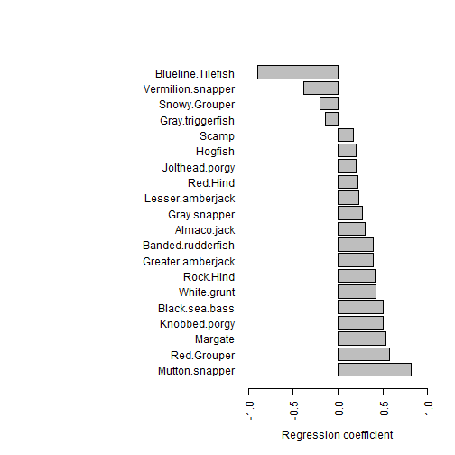

Figure 2. Method 1: Absolute difference between observed and predicted number of positive gag trips. Left and right panels differ only in the range of probabilities shown.

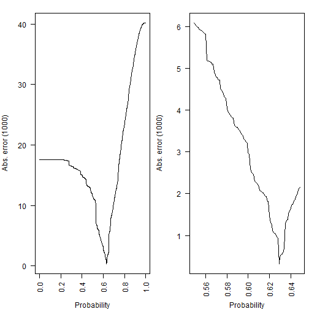

Figure 3. Method 2: Estimates of species-specific regression coefficients used to estimate a trip's probability of catching gag.

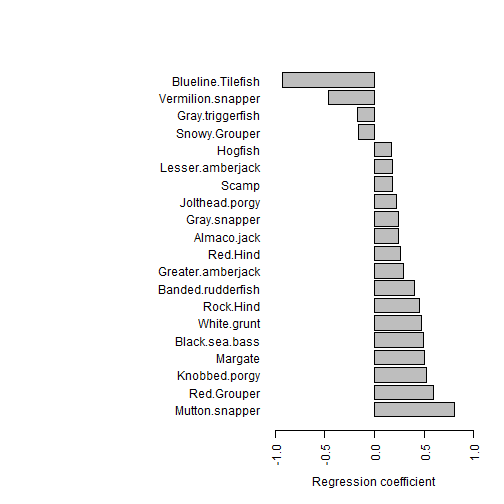

Figure 4. Method 2: Absolute difference between observed and predicted number of positive gag trips. Left and right panels differ only in the range of probabilities shown.

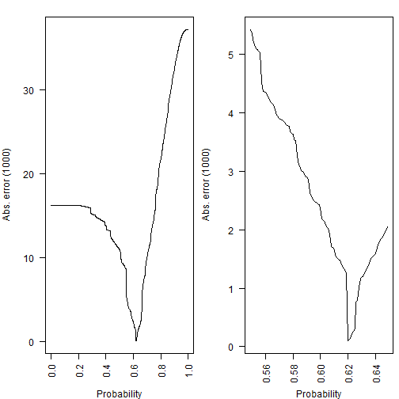

Figure 5. Method 3: Estimates of species-specific regression coefficients used to estimate a trip's probability of catching gag.

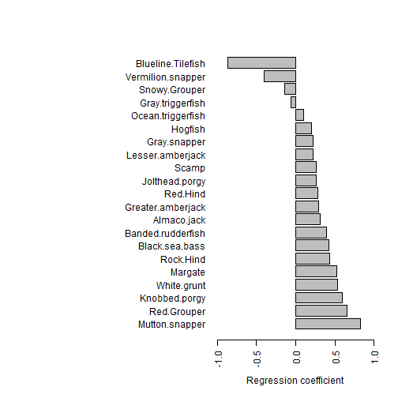

Figure 6. Method 3: Absolute difference between observed and predicted number of positive gag trips. Left and right panels differ only in the range of probabilities shown.

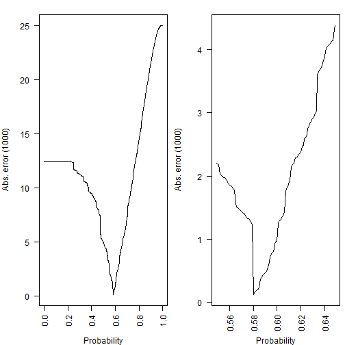

Figure 7. Method 4: Estimates of species-specific regression coefficients used to estimate a trip's probability of catching gag.

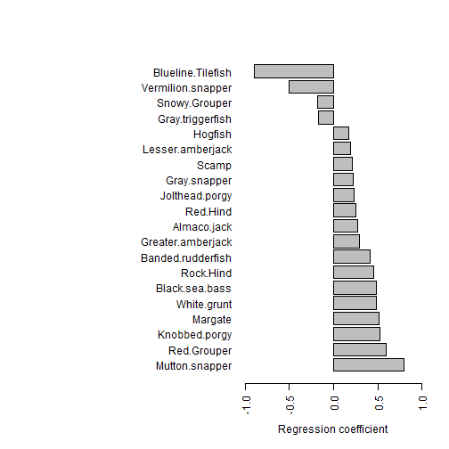

Figure 8. Method 4: Absolute difference between observed and predicted number of positive gag trips. Left and right panels differ only in the range of probabilities shown.

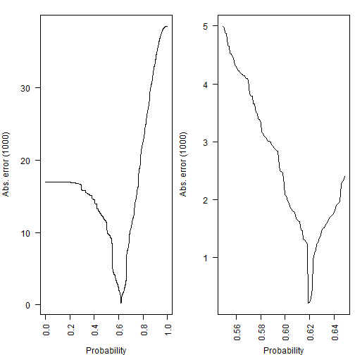

Figure 9. Estimated index for the four methods using a lognormal error distribution.

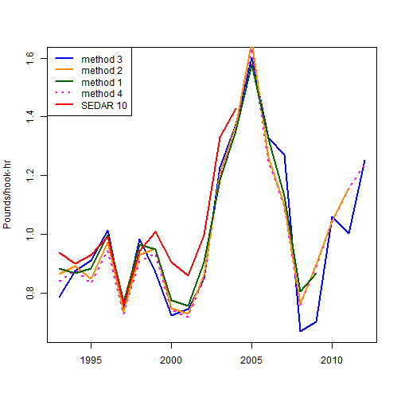

Figure 10. Diagnostics of lognormal model fits to positive CPUE data. The histogram of empirical log CPUE, with the normal distribution (empirical mean and variance) overlaid.

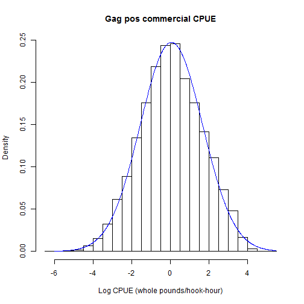

Figure 11. Quantile-quantile plot of residuals from the fitted model.

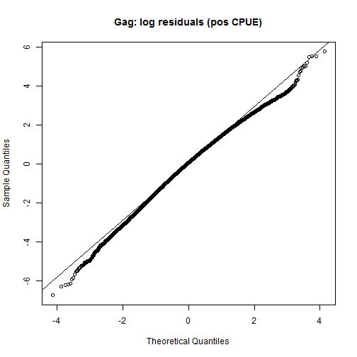

Figure 12. Raw residuals of lognormal model fits to positive CPUE for year. Box-and-whisker plots give first, second (median), and third quartiles, as well as limbs that extend approximately one interquartile range beyond the nearest quartile, and outliers (circles) beyond the limbs. Sample size is given along the upper whisker.

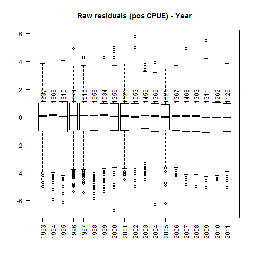

Figure 13. Raw residuals of lognormal model fits to positive CPUE for month. Sample size is given along the upper whisker.

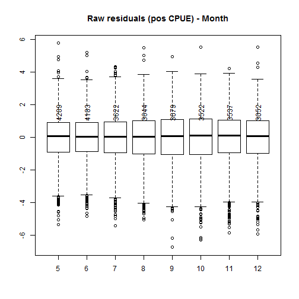

Figure 14. Raw residuals of lognormal model fits to positive CPUE for region. Sample size is given along the upper whisker.

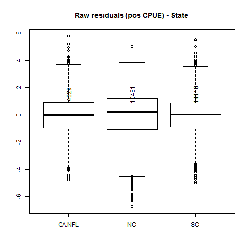

Figure 15. Raw residuals of lognormal model fits to positive CPUE for region by month. Sample size is given along the upper whisker.

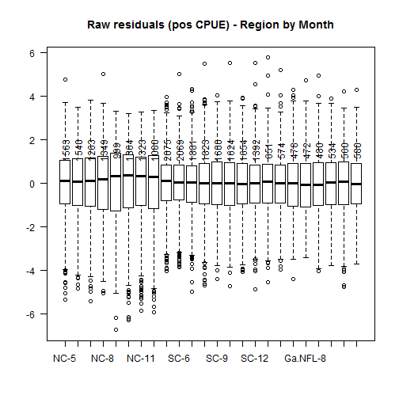

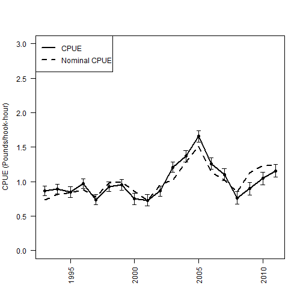